# Hacia los datos: gráficos y visualización

¿Te animas a aprender R y descubrir qué dicen los datos sobre redes sociales y salud mental?

# #Cuéntanos: ¿Qué te motivó a asistir al taller?

1. Abre tu cámara.
2. Escanea el código QR.

[figure not shown]

## Configuración Inicial

### El Directorio

¿Dónde está trabajando R? Define la ubicación física para leer tus archivos.

```r
getwd() # Ver ruta actual
dir() # Listar archivos disponibles
# choose.files()
setwd("C:\\Users\\sofia\\OneDrive\\Documentos\\2026-1\\GEA\\Taller2") # Cambiar de carpeta
```

### Gestión de Paquetes

Extiende las capacidades de R instalando nuevas librerías especializadas.

- **Instalación**: Se realiza una sola vez por equipo.
- **Carga**: Se debe hacer en cada sesión nueva de R.

```r
# install.packages("dplyr")
library(dplyr)
# install.packages("ggplot2")
library(ggplot2)
```

## Caso de Estudio e Importación

### Impacto de Redes

Los datos que se usarán en esta sesión provienen de **Kaggle**. Estos los pueden encontrar el siguiente [link](https://www.kaggle.com/datasets/sumeakash/impact-of-social-media-on-health).

Contienen información sobre el impacto de las plataformas digitales y la IA en estudiantes, tanto en su vida personal como académica.

- **Formato**: `.csv`
- **Lectura en R**: `read.csv()`

```r
df <- read.csv("Social_media_impact_on_life.csv")
```

### Tipos de archivos

R puede leer casi cualquier base de datos:

- Texto plano: CSV (*.csv*), TXT (*.txt*)
- Hojas de cálculo: Excel (*.xlsx*)
- Otros software: Stata (*.dta*), SAS (*.sas7bdat*)
- Formatos de R: RData (*.RData*), Rda (*.rda*)

Algunas funciones para importar archivos vienen preinstalados en R, pero otras requieren instalar paquetes adicionales. Por ejemplo, archivos *.xlsx*.

## Tipos de Variables

### Numéricas

Representan cantidades medibles y permiten operaciones matemáticas.

- **Discretas**: valores enteros (ej. número de hijos)
- **Continuas**: cualquier valor en un intervalo (ej. peso, altura)
- **Intervalo**: No tiene cero absoluto (ej. temperatura en °C)
- **Razón**: Tiene cero absoluto y permite comparaciones de proporción (ej. edad, ingresos, distancia)

### Categóricas

Representan cualidades o grupos.

- **Nominales**: sin orden (ej. género, color)
- **Ordinales**: con orden (ej. nivel educativo, satisfacción)

## Inspección de Variables

¿Cómo podemos ver las variables de nuestro conjunto de datos?

```r
# names(df)
summary(df)
```

```
   Student_ID          Age           Gender          Academic_Level
 Min.   :   1.0   Min.   :18.00   Length:1705        Length:1705
 1st Qu.: 214.0   1st Qu.:19.00   Class :character   Class :character
 Median : 427.0   Median :21.00   Mode  :character   Mode  :character
 Mean   : 439.5   Mean   :20.85
 3rd Qu.: 640.0   3rd Qu.:22.00
 Max.   :1000.0   Max.   :24.00
   Country          Avg_Daily_Usage_Hours Most_Used_Platform
 Length:1705        Min.   :1.500         Length:1705
 Class :character   1st Qu.:3.800         Class :character
 Mode  :character   Median :5.100         Mode  :character
                    Mean   :5.104
                    3rd Qu.:6.300
                    Max.   :8.500
 Affects_Academic_Performance Sleep_Hours_Per_Night Mental_Health_Score
 Length:1705                  Min.   :3.800         Min.   :4.000
 Class :character             1st Qu.:5.600         1st Qu.:5.000
 Mode  :character             Median :6.600         Median :6.000
                              Mean   :6.599         Mean   :6.215
                              3rd Qu.:7.500         3rd Qu.:7.000
                              Max.   :9.600         Max.   :9.000
 Overall_Impact
 Length:1705
 Class :character
 Mode  :character
```

**Actividad:**

Elijan una variable:

- ¿Qué representa?
- ¿Qué tipo de variable creen que es?

## Descripción de las variables

**Diccionario de Datos**

[output not shown]

```r
head(df, n = 4)
```

```
  Student_ID Age Gender Academic_Level Country Avg_Daily_Usage_Hours
1        232  21   Male  Undergraduate   Other                   4.0
2        564  23 Female  Undergraduate   Other                   1.6
3        788  22   Male       Graduate  Canada                   4.6
4        686  18   Male  Undergraduate   Other                   7.0
  Most_Used_Platform Affects_Academic_Performance Sleep_Hours_Per_Night
1           Facebook                           No                   6.7
2           LinkedIn                           No                   8.6
3          Instagram                           No                   6.7
4           Snapchat                          Yes                   5.4
  Mental_Health_Score Overall_Impact
1                 6.8        Neutral
2                 7.6       Positive
3                 7.0        Neutral
4                 5.3       Negative
```

## Identificación de Datos Faltantes (NA)

### Concepto

**NA (Not Available)**: Representa la ausencia física de información. Es un valor lógico especial que indica que el dato no fue capturado o se perdió.

**Impacto crítico** Su presencia puede reducir el tamaño efectivo de la muestra cuando se eliminan observaciones incompletas, además de introducir sesgos estadísticos si los datos faltantes no ocurren de manera aleatoria.

### Detección en R

```r
colSums(is.na(df))
```

```
                  Student_ID                          Age
                           0                            0
                      Gender               Academic_Level
                           0                            0
                     Country        Avg_Daily_Usage_Hours
                           0                            0
          Most_Used_Platform Affects_Academic_Performance
                           0                            0
       Sleep_Hours_Per_Night          Mental_Health_Score
                           0                            0
              Overall_Impact
                           0
```

## Medidas Estadísticas

### Cualitativa

- **Frecuencia:**
  - Absoluta (conteo)
  - Relativa (%)
- **Moda:** Categoría más repetida.

No permiten operaciones matemáticas porque sus valores son etiquetas o categorías, no cantidades.

- No representan magnitudes numéricas
- No tienen un orden o distancia definida entre ellas

### Cuantitativa

- **Tendencia Central:** Media, Mediana, Moda.
- **Dispersión:** Desviación estándar, Varianza, Rango, Rango intercuartílico.
- **Posición:** Cuartiles, Deciles, Percentiles.
- **Forma:** Asimetría, Curtosis.
- **Relación:** Covarianza, Correlación.

## Sintaxis de dplyr

### El Pipe `|>` , `%>%`

Se utiliza para encadenar múltiples operaciones de forma legible.

- Instalación y carga

```r
# install.packages("dplyr")
library(dplyr)
```

- **Sintaxis:** `datos |> operacion()`
- Facilita la lectura de “arriba hacia abajo”.

El pipe original es `%>%`, pero desde R 4.1 se recomienda el nativo `|>`.

### Funciones principales

Dplyr se basa en una “gramática” de manipulación de datos:

1. `filter()`: Selecciona filas basándose en sus valores.
2. `select()`: Selecciona columnas.
3. `mutate()`: Crea nuevas variables o transforma las existentes.
4. `arrange()`: Ordena las filas.
5. `group_by()`: Agrupa el conjunto de datos por una o más variables.
6. `summarise()`: Reduce un conjunto de datos a medidas resumen que describen la información.

Las funciones devuelven un nuevo dataframe. No modifican el objeto original a menos que se sobrescriba.

## select() + mutate()

¿Qué variables del dataset son relevantes para analizar el impacto de redes sociales en la salud mental?

```r
df_select <- df %>%
  select(Age, Gender, Mental_Health_Score,
         Avg_Daily_Usage_Hours, Sleep_Hours_Per_Night,
         Overall_Impact) %>%
  mutate(Uso_Categoria = case_when(
    Avg_Daily_Usage_Hours < 2 ~ "Bajo",
    Avg_Daily_Usage_Hours >= 2 & Avg_Daily_Usage_Hours <= 5 ~ "Moderado",
    Avg_Daily_Usage_Hours > 5 ~ "Intenso"
  ))

df_select1 <- df %>%
  select(-Student_ID)

head(df_select,4)
```

```
  Age Gender Mental_Health_Score Avg_Daily_Usage_Hours Sleep_Hours_Per_Night
1  21   Male                 6.8                   4.0                   6.7
2  23 Female                 7.6                   1.6                   8.6
3  22   Male                 7.0                   4.6                   6.7
4  18   Male                 5.3                   7.0                   5.4
  Overall_Impact Uso_Categoria
1        Neutral      Moderado
2       Positive          Bajo
3        Neutral      Moderado
4       Negative       Intenso
```

### Ejercicio

¿Qué tipo de variables predominan en el dataset?

```r
df_cuan <- df %>%
  select(Age, Avg_Daily_Usage_Hours,
         Sleep_Hours_Per_Night,Mental_Health_Score)

df_cat <- df %>%
  select(Gender, Academic_Level,
         Country,Most_Used_Platform,
         Affects_Academic_Performance,Overall_Impact)
```

## filter() + arrange()

¿Cómo cambia el puntaje de salud mental en estudiantes que usan redes más de 5 horas al día?

```r
df_filter <- df %>%
  filter(Avg_Daily_Usage_Hours > 5) %>%
  select(Avg_Daily_Usage_Hours, Mental_Health_Score)  %>%
  arrange(Mental_Health_Score)

head(df_filter,7)
```

```
  Avg_Daily_Usage_Hours Mental_Health_Score
1                   7.5                   4
2                   7.3                   4
3                   8.0                   4
4                   5.9                   4
5                   8.2                   4
6                   7.1                   4
7                   7.0                   4
```

filter() permite usar múltiples condiciones separadas por comas.

### Ejercicio

¿Qué estudiantes duermen menos de 6 horas y usan redes más de 4 horas?

```r
df_filter1 <- df_select %>%
  filter(Sleep_Hours_Per_Night < 6,
         Avg_Daily_Usage_Hours > 4)

head(df_filter1,4)
```

```
  Age Gender Mental_Health_Score Avg_Daily_Usage_Hours Sleep_Hours_Per_Night
1  18   Male                 5.3                   7.0                   5.4
2  24 Female                 4.4                   7.5                   5.0
3  22 Female                 5.3                   8.0                   5.2
4  21 Female                 4.7                   6.0                   5.7
  Overall_Impact Uso_Categoria
1       Negative       Intenso
2       Negative       Intenso
3       Negative       Intenso
4       Negative       Intenso
```

## group_by() + summarise()

¿Cuál es el promedio del puntaje de salud mental por género?

```r
df %>%
  group_by(Gender) %>%
  summarise(Prom = mean(Mental_Health_Score))
```

```
# A tibble: 2 × 2
  Gender  Prom
  <chr>  <dbl>
1 Female  6.16
2 Male    6.27
```

¿Cómo varía el uso promedio según nivel académico?

```r
df %>%
  group_by(Academic_Level) %>%
  summarise(Prom = mean(Avg_Daily_Usage_Hours))
```

```
# A tibble: 3 × 2
  Academic_Level  Prom
  <chr>          <dbl>
1 Graduate        4.99
2 High School     5.28
3 Undergraduate   5.12
```

### Ejercicio

¿Qué aplicación tiene más impacto negativo?

```r
df %>%
  filter(Overall_Impact == "Negative") %>%
  group_by(Most_Used_Platform) %>%
  summarise(Num = n()) %>%
  filter(Num == max(Num))
```

```
# A tibble: 1 × 2
  Most_Used_Platform   Num
  <chr>              <int>
1 Instagram            241
```

## Sintaxis de ggplot2

```r
# install.packages("ggplot2")
library(ggplot2)
ggplot(data,
       # MAPEO (Aes): Aquí se conectan las columnas de los datos
       mapping = aes(x = var1,      # Eje X
                     y = var2          # Eje y
                     )) +
  # GEOMETRÍA (Geom): Define qué forma física tomarán esos datos
  geom_point()
```

### Datos (data)

Información estructurada que se desea graficar.

- **Formato:** `data.frame` o `tibble`
- **Ubicación:** argumento dentro de `ggplot()`

### Mapeo (aes)

Relación entre variables y atributos visuales.

- • `x`, `y`: ejes
- • `color`: borde
- • `fill`: relleno
- • `size`: tamaño
- • `shape`: forma
- • `alpha`: opacidad

### Geometría (geom)

La capa que define el tipo de gráfico.

- `geom_point()` → dispersión
- `geom_line()` → líneas
- `geom_bar()` → barras
- `geom_boxplot()` → cajas
- `geom_histogram()` → histogramas

## Gráficos para variables cualitativas

### Gráfico de barras

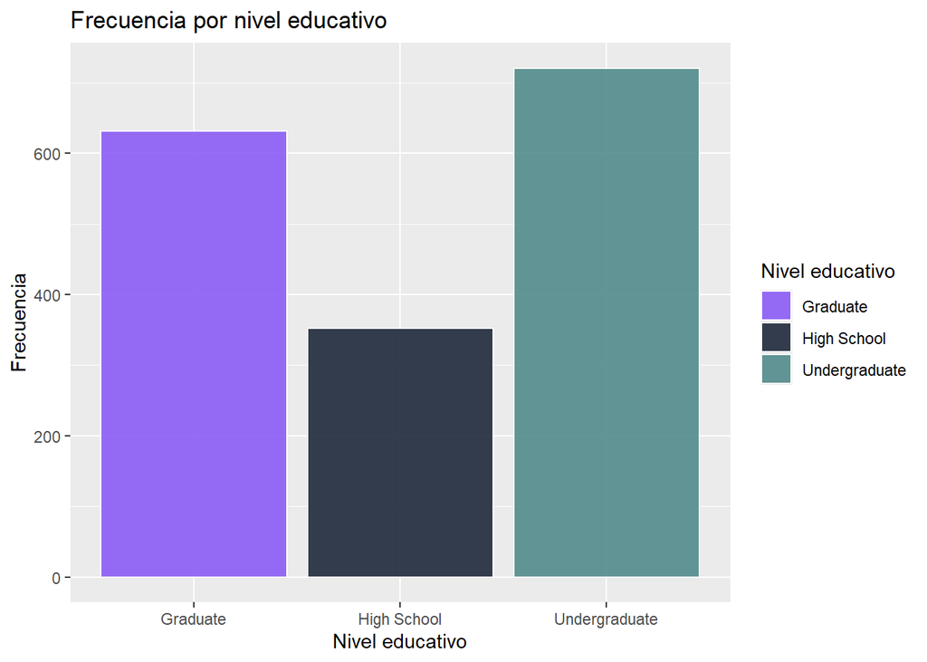

```r
ggplot(df, aes(x = Academic_Level, fill = Academic_Level)) +
  geom_bar(
    color = "white",
    linewidth = 0.5,
    alpha = 0.9
  ) +
  scale_fill_manual(
    values = c(
      "#8b5cf6",
      "#1e293b",
      "#528B8B"
    )
  ) +
  labs(
    title = "Frecuencia por nivel educativo",
    x = "Nivel educativo",
    y = "Frecuencia",
    fill = "Nivel educativo"
  )
```

### Gráfico de pastel

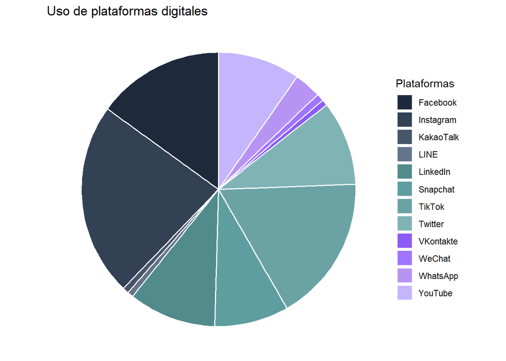

```r
ggplot(df, aes(x = "", fill = Most_Used_Platform)) +
  geom_bar(
    width = 1,
    color = "white",
    linewidth = 0.7
  ) +
  coord_polar(theta = "y") +
  scale_fill_manual(
  values = c(
    "#1e293b",
    "#334155",
    "#475569",
    "#64748b",
    "#528B8B",
    "#5f9ea0",
    "#6ba3a5",
    "#7fb3b5",
    "#8b5cf6",
    "#9f75ff",
    "#b794f4",
    "#c4b5fd"
  )
) +
  labs(
    title = "Uso de plataformas digitales",
    fill = "Plataformas"
  ) +
  theme_void()
```

## Gráficos para variables cuantitativas

### Histograma

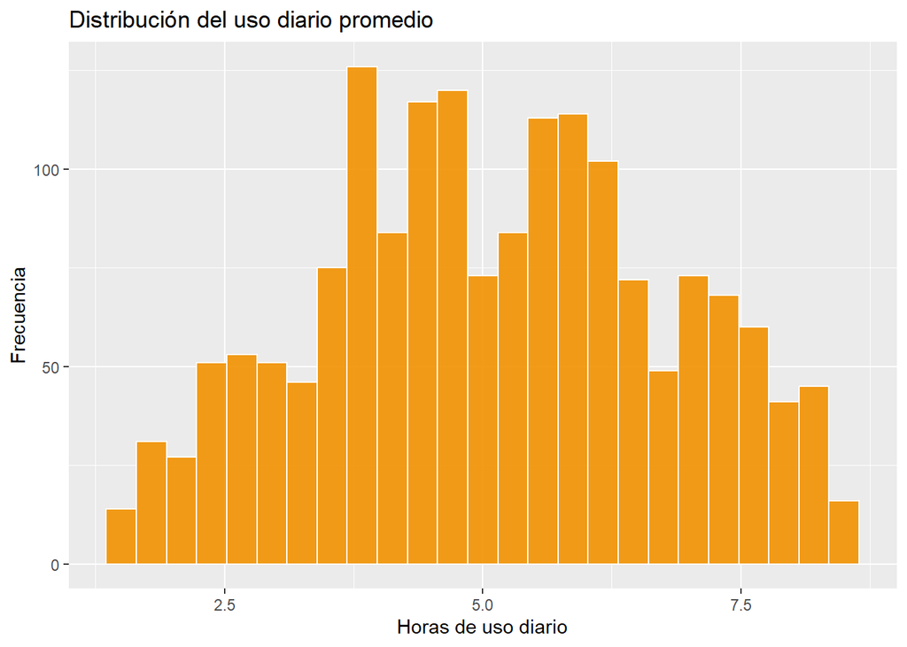

```r
ggplot(df, aes(x = Avg_Daily_Usage_Hours)) +
  geom_histogram(
    bins = 25, # Cantidad de barras
    fill = "#f29100",
    color = "white",  # Color del borde de las barras
    linewidth = 0.4, # Grosor del borde de cada barra
    alpha = 0.9 # Nivel de transparencia
  ) +
  labs(
    title = "Distribución del uso diario promedio",
    x = "Horas de uso diario",
    y = "Frecuencia"
  )
```

### Bloxplot

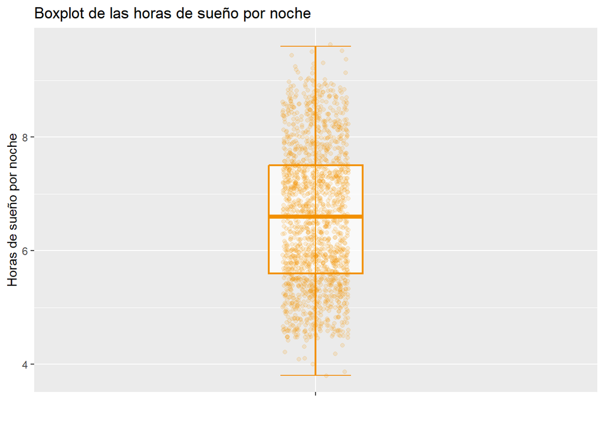

```r
ggplot(
  df, aes(x='',y = Sleep_Hours_Per_Night)) +
  geom_boxplot(
    color = "#f29100",
    size = 0.8,
    width = 0.2,
    alpha = 0.7
  ) +
  stat_boxplot(
    geom = "errorbar",
    width = 0.15,
    color = "#f29100"
  ) +
  geom_jitter(
  width = 0.07,
  color = "#f29100",
  alpha = 0.15
  ) +
  labs(
    title = "Boxplot de las horas de sueño por noche",
    x = '',
    y = "Horas de sueño por noche"
  )
```

## Análisis gráfico entre dos variables

### Boxplot

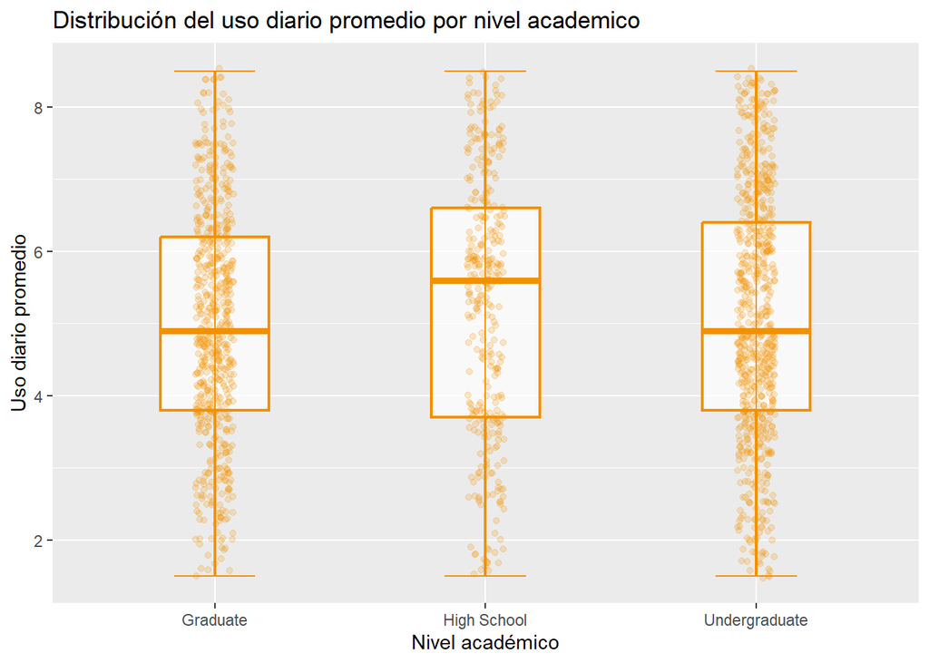

```r
ggplot(df, aes(x = Academic_Level , y= Avg_Daily_Usage_Hours)) +
  geom_boxplot(
    color = "#f29100",
    size = 0.8,
    width = 0.4,
    alpha = 0.7
  ) +
  stat_boxplot(
    geom = "errorbar",
    width = 0.3,
    color = "#f29100"
  ) +
  geom_jitter(
  width = 0.07,
  color = "#f29100",
  alpha = 0.2
  ) +
  labs(
    title = "Distribución del uso diario promedio por nivel academico",
    x = "Nivel académico",
    y = "Uso diario promedio"
  )
```

### Gráfico de dispersión

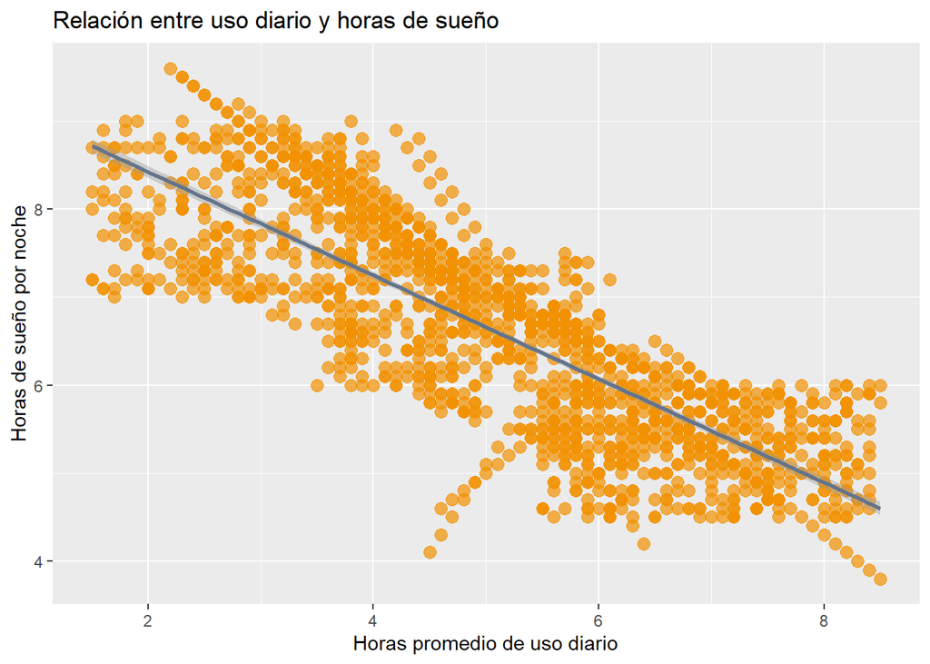

```r
ggplot(
  df, aes( x = Avg_Daily_Usage_Hours, y = Sleep_Hours_Per_Night)) +
  geom_point(
    color = "#f29100",
    size = 3,
    alpha = 0.7
  ) +
  geom_smooth(
    method = "lm",
    se = TRUE,
    color = "#64748b",
    linewidth = 1
  ) +
  labs(
    title = "Relación entre uso diario y horas de sueño",
    x = "Horas promedio de uso diario",
    y = "Horas de sueño por noche"
  )
```

## ¿Se puede engañar con gráficos?

Veamos cómo un mismo conjunto de datos puede transmitir mensajes completamente distintos dependiendo de la escala utilizada.

### Preparación de los datos

```r
df_plot <- df %>%
  group_by(Overall_Impact) %>%
  summarise(
    promedio = mean(
      Avg_Daily_Usage_Hours,
      na.rm = TRUE
    )
  )
```

### Gráfico correcto

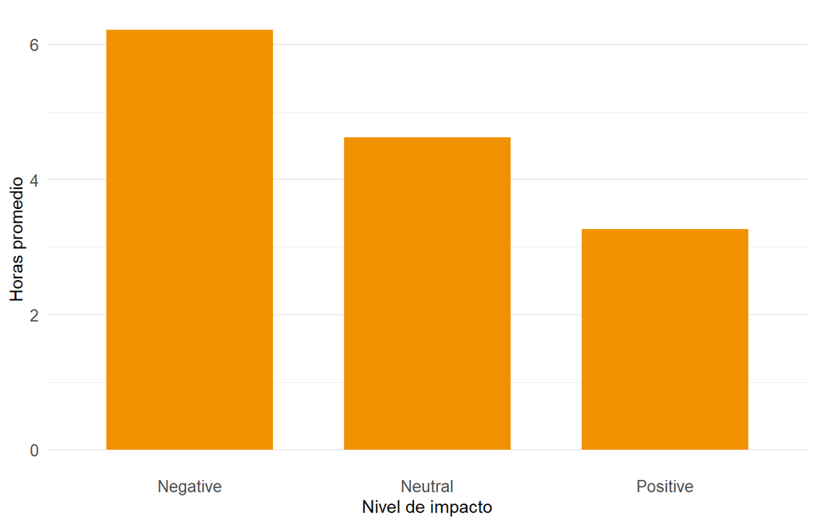

```r
ggplot(
  df_plot,
  aes(
    x = factor(Overall_Impact),
    y = promedio
  )
) +
  geom_col(
    fill = "#f29100",
    width = 0.7
  ) +
  labs(
    x = "Nivel de impacto",
    y = "Horas promedio"
  ) +
  theme_minimal() +
  theme(
    plot.title = element_blank(),
    panel.grid.major.x = element_blank(),
    axis.title = element_text(size = 11),
    axis.text = element_text(size = 10)
  )
```

La escala inicia en cero, por lo que las diferencias entre grupos se representan de forma proporcional y objetiva.

### Gráfico manipulado

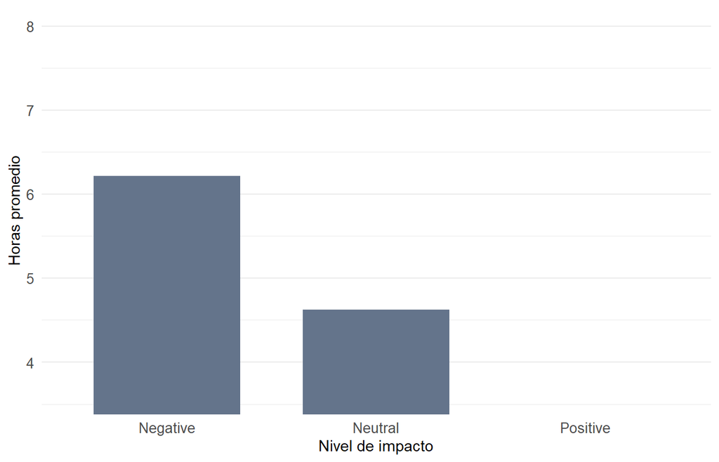

```r
ggplot(
  df_plot,
  aes(
    x = factor(Overall_Impact),
    y = promedio
  )
) +
  geom_col(
    fill = "#64748b",
    width = 0.7
  ) +
  coord_cartesian(
    ylim = c(3.6, 8)
  ) +
  labs(
    x = "Nivel de impacto",
    y = "Horas promedio"
  ) +
  theme_minimal() +
  theme(
    plot.title = element_blank(),
    panel.grid.major.x = element_blank(),
    axis.title = element_text(size = 11),
    axis.text = element_text(size = 10)
  )
```

Al recortar el eje Y, las diferencias parecen mucho más grandes de lo que realmente son, generando una interpretación engañosa.

# ¡Gracias!

Gracias por acompañarnos en esta sesión.  
Esperamos verlos próximamente en **GEA**  
y en las siguientes sesiones

¡Nos vemos en la próxima sesión!